# Life-Expectancy-Analysis

#### BIC

```r
bic_min <- which.min(data_bs_sum$bic)
bic_min
```

```
## [1] 9
```

```r
data_bs_sum$bic[bic_min]
```

```
## [1] -2879.503
```

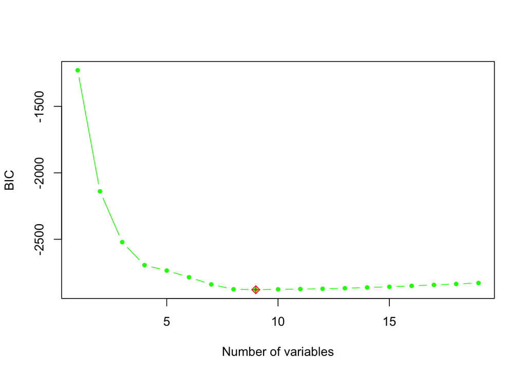

```r
plot(data_bs_sum$bic, xlab = "Number of variables", ylab = "BIC", col = "green",
     type = "b", pch = 20)
points(bic_min, data_bs_sum$bic[bic_min], col = "red", pch = 9)
```

Based on BIC metrics the best model is model with 9 variables.

#### RSQ

```r
rsq_max <- which.max(data_bs_sum$rsq)
rsq_max
```

```
## [1] 19
```

```r
data_bs_sum$rsq[rsq_max]
```

```
## [1] 0.8355665
```

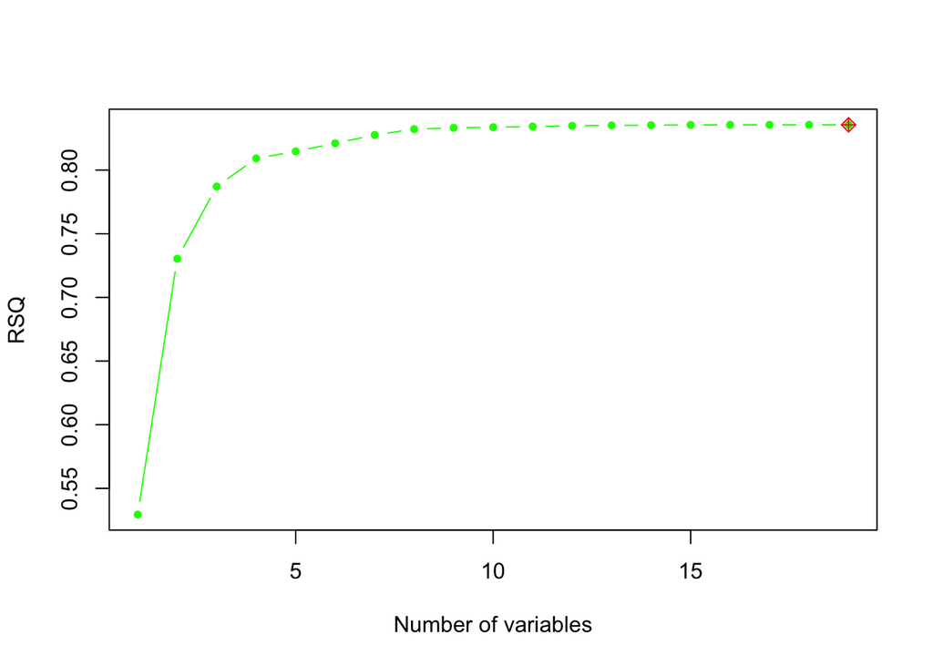

```r
plot(data_bs_sum$rsq, xlab = "Number of variables", ylab = "RSQ", col = "green",
     type = "b", pch = 20)
points(rsq_max, data_bs_sum$rsq[rsq_max], col = "red", pch = 9)
```

Based on R Squared metric the best model is model with 19 variables.

#### ADJR

```r
adjr_max <- which.max(data_bs_sum$adjr)
adjr_max
```

```
## [1] 15
```

```r
data_bs_sum$adjr[adjr_max]
```

```
## [1] 0.8339771
```

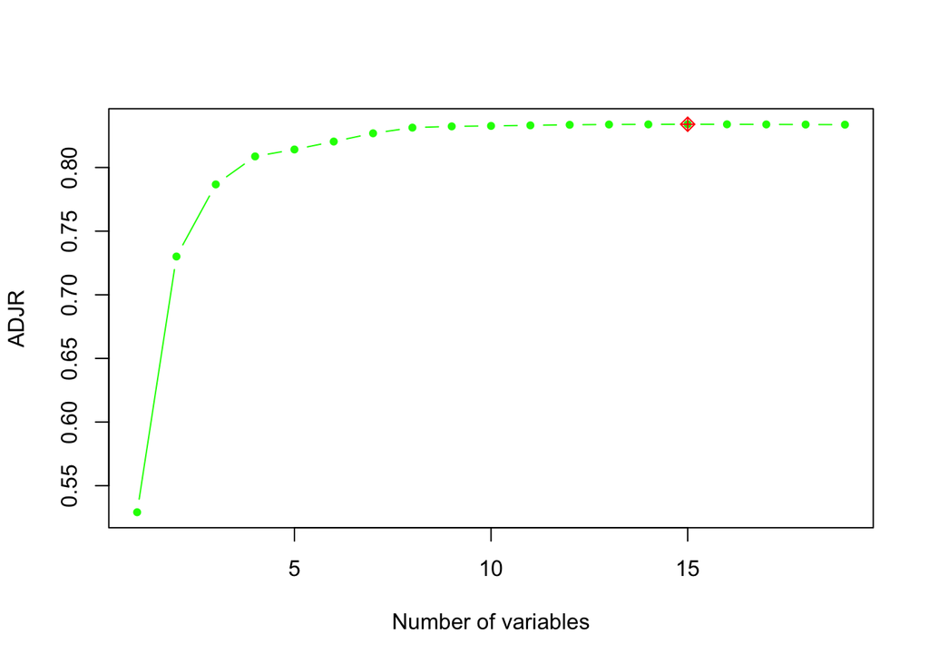

```r
plot(data_bs_sum$adjr, xlab = "Number of variables", ylab = "ADJR", col = "green",
     type = "b", pch = 20)
points(adjr_max, data_bs_sum$adjr[adjr_max], col = "red", pch = 9)
```

Based on Adjusted R Squared metric the best model is model with 15 variables.

#### CP

```r
cp_min <- which.min(data_bs_sum$cp)
cp_min
```

```
## [1] 13
```

```r
data_bs_sum$cp[cp_min]
```

```
## [1] 12.60294
```

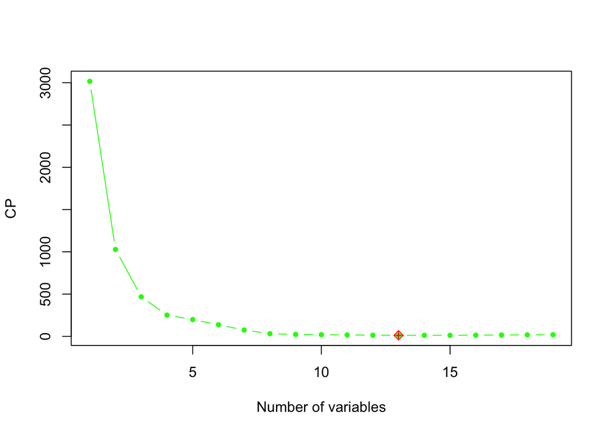

```r
plot(data_bs_sum$cp, xlab = "Number of variables", ylab = "CP", col = "green",
     type = "b", pch = 20)
points(cp_min, data_bs_sum$cp[cp_min], col = "red", pch = 9)
```

Based on Cp metric the best model is model with 13 variables.

### Backward and forward selection

#### Forward

```r
data_fwd <- regsubsets(Life.expectancy ~ .,data = data_not_scaled, nvmax = 19, method = "forward")
data_sum_fwd <- summary(data_fwd)
with(data_sum_fwd, data.frame(rsq, adjr2, cp, rss, outmat))
```

```
##                 rsq     adjr2         cp      rss StatusDeveloping
## 1  ( 1 )  0.5294455 0.5291598 3016.66256 60009.50
## 2  ( 1 )  0.7303904 0.7300628 1027.95333 34383.13
## 3  ( 1 )  0.7870954 0.7867071  468.19133 27151.58
## 4  ( 1 )  0.8091754 0.8087111  251.44988 24335.73
## 5  ( 1 )  0.8147121 0.8141483  198.59920 23629.63
## 6  ( 1 )  0.8200541 0.8193966  147.67739 22948.37
## 7  ( 1 )  0.8229145 0.8221591  121.34046 22583.59
## 8  ( 1 )  0.8242847 0.8234276  109.76579 22408.85
## 9  ( 1 )  0.8332293 0.8323136   23.15403 21268.15
## 10  ( 1 ) 0.8336936 0.8326783   20.55469 21208.94                *
## 11  ( 1 ) 0.8342308 0.8331169   17.23229 21140.43                *
## 12  ( 1 ) 0.8347580 0.8335460   14.00975 21073.20                *
## 13  ( 1 ) 0.8351019 0.8337908   12.60294 21029.34                *
## 14  ( 1 ) 0.8352767 0.8338654   12.87124 21007.05                *
```

[output cut: 85 more lines]

```r
# BIC
bic_min <- which.min(data_sum_fwd$bic)
bic_min
```

```
## [1] 9
```

```r
data_sum_fwd$bic[bic_min]
```

```
## [1] -2879.503
```

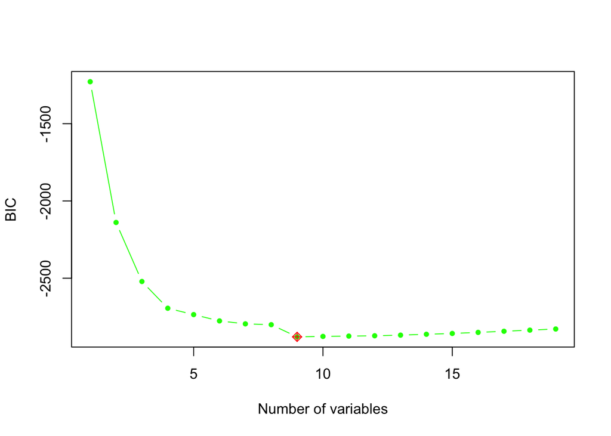

```r
plot(data_sum_fwd$bic, xlab = "Number of variables", ylab = "BIC", col = "green",
     type = "b", pch = 20)
points(bic_min, data_sum_fwd$bic[bic_min], col = "red", pch = 9)
```

According to BIC metrics best model has 9 variables:

- Adult.Mortality
- infant.deaths
- percentage.expenditure
- BMI
- under.five.deaths
- Diphtheria
- HIV.AIDS
- Income.composition.of.resources
- Schooling

```r
#RSQ
cp_min <- which.min(data_sum_fwd$cp)
cp_min
```

```
## [1] 13
```

```r
data_sum_fwd$cp[cp_min]
```

```
## [1] 12.60294
```

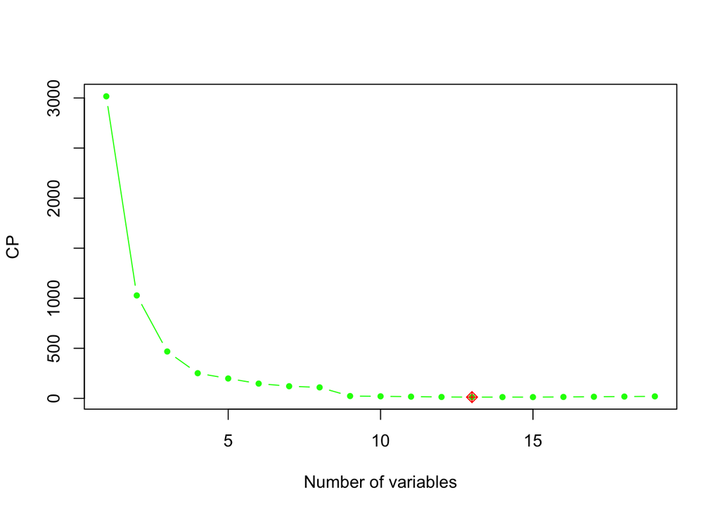

```r
plot(data_sum_fwd$cp, xlab = "Number of variables", ylab = "CP", col = "green",
     type = "b", pch = 20)
points(cp_min, data_sum_fwd$cp[cp_min], col = "red", pch = 9)
```

```r
#AJDR
adjr_max <- which.max(data_sum_fwd$adjr)
adjr_max
```

```
## [1] 15
```

```r
data_sum_fwd$adjr[adjr_max]
```

```
## [1] 0.8339771
```

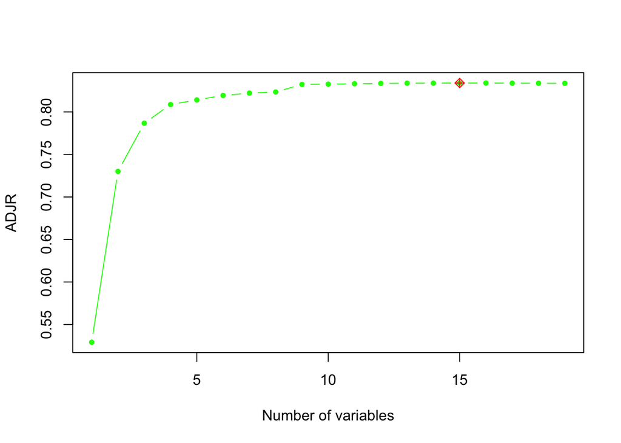

```r
plot(data_sum_fwd$adjr, xlab = "Number of variables", ylab = "ADJR", col = "green",
     type = "b", pch = 20)
points(adjr_max, data_sum_fwd$adjr[adjr_max], col = "red", pch = 9)
```

According to Adjusted R Squared metrics best model has 15 variables:

- Status.Developing
- Adult.Mortality
- infant.deaths
- Alcohol
- percentage.expenditure
- Hepatitis
- BMI
- Polio
- under.five.deaths
- Total.expenditure
- Diphtheria
- HIV.AIDS
- thinness.5.9.years
- Income.composition.of.resources
- Schooling

#### Backward

```r
data_bwd <- regsubsets(Life.expectancy ~ .,data = data_not_scaled, nvmax = 19, method = "backward")
data_sum_bwd <- summary(data_bwd)
with(data_sum_bwd, data.frame(rsq, adjr2, cp, rss, outmat))
```

```
##                 rsq     adjr2         cp      rss StatusDeveloping
## 1  ( 1 )  0.5294455 0.5291598 3016.66256 60009.50
## 2  ( 1 )  0.7303904 0.7300628 1027.95333 34383.13
## 3  ( 1 )  0.7870954 0.7867071  468.19133 27151.58
## 4  ( 1 )  0.8091754 0.8087111  251.44988 24335.73
## 5  ( 1 )  0.8121763 0.8116047  223.72068 23953.02
## 6  ( 1 )  0.8210398 0.8203859  137.91219 22822.67
## 7  ( 1 )  0.8276030 0.8268676   74.89295 21985.67
## 8  ( 1 )  0.8321399 0.8313211   31.94677 21407.08
## 9  ( 1 )  0.8332293 0.8323136   23.15403 21268.15
## 10  ( 1 ) 0.8336936 0.8326783   20.55469 21208.94                *
## 11  ( 1 ) 0.8342308 0.8331169   17.23229 21140.43                *
## 12  ( 1 ) 0.8347580 0.8335460   14.00975 21073.20                *
## 13  ( 1 ) 0.8351019 0.8337908   12.60294 21029.34                *
## 14  ( 1 ) 0.8352767 0.8338654   12.87124 21007.05                *
```

[output cut: 85 more lines]

```r
# BIC
bic_min <- which.min(data_sum_bwd$bic)
bic_min
```

```
## [1] 9
```

```r
data_sum_bwd$bic[bic_min]
```

```
## [1] -2879.503
```

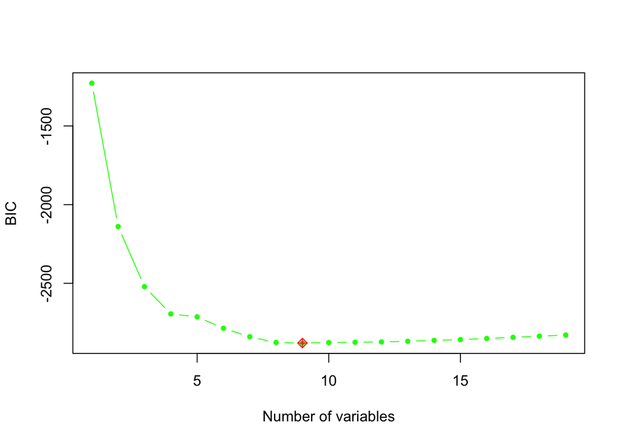

```r
plot(data_sum_bwd$bic, xlab = "Number of variables", ylab = "BIC", col = "green",
     type = "b", pch = 20)
points(bic_min, data_sum_bwd$bic[bic_min], col = "red", pch = 9)
```

```r
#RSQ
cp_min <- which.min(data_sum_bwd$cp)
cp_min
```

```
## [1] 13
```

```r
data_sum_bwd$cp[cp_min]
```

```
## [1] 12.60294
```

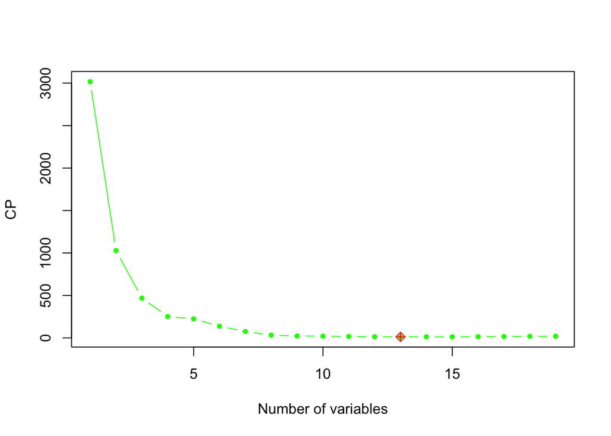

```r
plot(data_sum_bwd$cp, xlab = "Number of variables", ylab = "CP", col = "green",
     type = "b", pch = 20)
points(cp_min, data_sum_bwd$cp[cp_min], col = "red", pch = 9)
```

```r
#AJDR
adjr_max <- which.max(data_sum_bwd$adjr)
adjr_max
```

```
## [1] 15
```

```r
data_sum_bwd$adjr[adjr_max]
```

```
## [1] 0.8339771
```

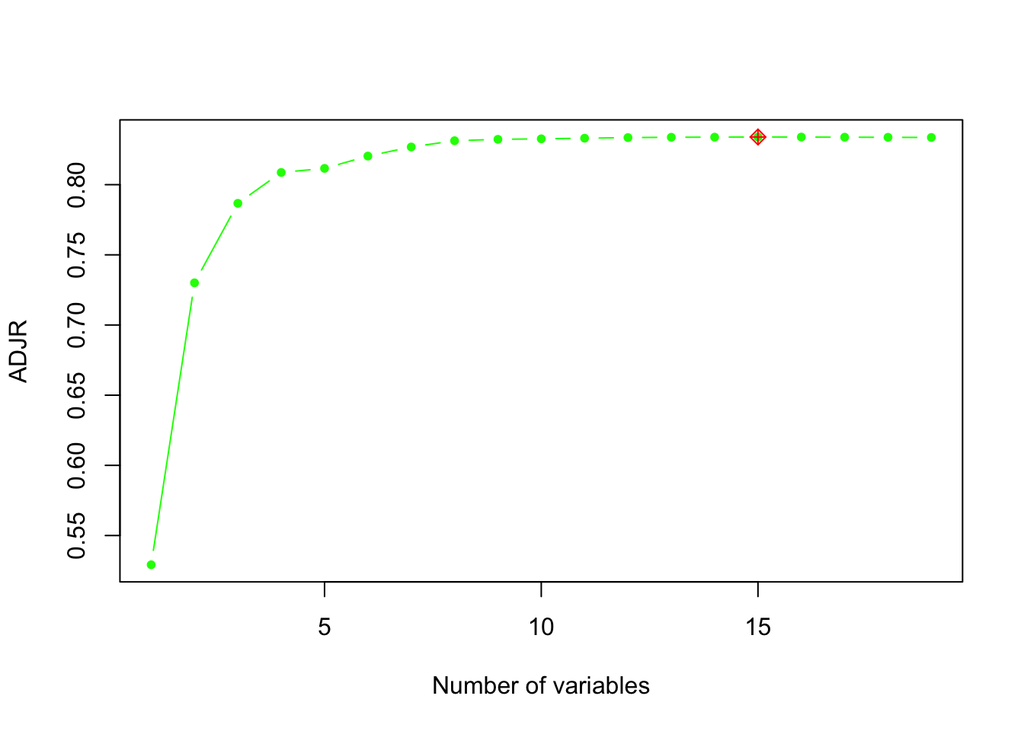

```r
plot(data_sum_bwd$adjr, xlab = "Number of variables", ylab = "ADJR", col = "green",
     type = "b", pch = 20)
points(adjr_max, data_sum_bwd$adjr[adjr_max], col = "red", pch = 9)
```

All of the considered metric for backwars selection give the same results as for forward selection.

## Validation set selection

```r
#data <- data[,-20]
# n <- nrow(data[,-20])
# train <- sample(c(TRUE, FALSE), n, replace = TRUE)
# test <- !train
# data_bs_v <- regsubsets(Life.expectancy ~ ., data = data[train,-20], nvmax = 18)

n <- nrow(data_not_scaled)
train <- sample(c(TRUE, FALSE), n, replace = TRUE)
test <- !train
data_bs_v <- regsubsets(Life.expectancy ~ ., data = data_not_scaled, nvmax = 19)
```

```r
predict.regsubsets <- function(object, newdata, id, ...) {
  model_formula <- as.formula(object$call[[2]])
  mat <- model.matrix(model_formula, newdata)
  coefs <- coef(object, id = id)
  mat[, names(coefs)] %*% coefs
}
```

```r
set.seed(123)
prediction_error <- function(i, model, subset) {
  pred <- predict(model, data_not_scaled[subset,], id = i)
  mean((data_not_scaled$Life.expectancy[subset] - pred)^2)
}
val_errors <- sapply(1:19, prediction_error, model = data_bs_v, subset = test)
val_errors
```

```
##  [1] 37.26005 20.74287 15.75773 14.28001 13.87769 13.29390 12.83587 12.58218
##  [9] 12.48031 12.40938 12.46585 12.46387 12.42469 12.38839 12.37079 12.36200
## [17] 12.35724 12.35621 12.35973
```

To find optimal number of variables we look for the smallest error estimation on validation set. In this situation it is 18.

Variables with “TRUE” are the variabled included in that model:

```r
summary(data_bs_v)$which[18, ]
```

```
##                     (Intercept)                StatusDeveloping
##                            TRUE                            TRUE
##                 Adult.Mortality                   infant.deaths
##                            TRUE                            TRUE
##                         Alcohol          percentage.expenditure
##                            TRUE                            TRUE
##                     Hepatitis.B                         Measles
##                            TRUE                            TRUE
##                             BMI               under.five.deaths
##                            TRUE                            TRUE
##                           Polio               Total.expenditure
##                            TRUE                            TRUE
##                      Diphtheria                        HIV.AIDS
##                            TRUE                            TRUE
##                             GDP                      Population
##                            TRUE                            TRUE
##            thinness..1.19.years              thinness.5.9.years
##                           FALSE                            TRUE
## Income.composition.of.resources                       Schooling
##                            TRUE                            TRUE
```

```r
data_bs_v_opt <- regsubsets(Life.expectancy ~ ., data = data_not_scaled, nvmax = 18)
data_bs_v_opt_sum <- summary(data_bs_v_opt)
with(data_bs_v_opt_sum, data.frame(rsq, adjr2, cp, rss, outmat))
```

```
##                 rsq     adjr2         cp      rss StatusDeveloping
## 1  ( 1 )  0.5294455 0.5291598 3016.66256 60009.50
## 2  ( 1 )  0.7303904 0.7300628 1027.95333 34383.13
## 3  ( 1 )  0.7870954 0.7867071  468.19133 27151.58
## 4  ( 1 )  0.8091754 0.8087111  251.44988 24335.73
## 5  ( 1 )  0.8147121 0.8141483  198.59920 23629.63
## 6  ( 1 )  0.8210398 0.8203859  137.91219 22822.67
## 7  ( 1 )  0.8276030 0.8268676   74.89295 21985.67
## 8  ( 1 )  0.8321399 0.8313211   31.94677 21407.08
## 9  ( 1 )  0.8332293 0.8323136   23.15403 21268.15
## 10  ( 1 ) 0.8336936 0.8326783   20.55469 21208.94                *
## 11  ( 1 ) 0.8342308 0.8331169   17.23229 21140.43                *
## 12  ( 1 ) 0.8347580 0.8335460   14.00975 21073.20                *
## 13  ( 1 ) 0.8351019 0.8337908   12.60294 21029.34                *
## 14  ( 1 ) 0.8352767 0.8338654   12.87124 21007.05                *
```

[output cut: 80 more lines]

## K - cross validation selection

```r
set.seed(123)
k <- 10
folds <- sample(1:k, n, replace = TRUE)
val_err <- NULL
for (j in 1:k) {
  fit_bs <- regsubsets(Life.expectancy ~ ., data = data_not_scaled[folds != j,], nvmax = 19)
  err <- sapply(1:19, prediction_error, model = fit_bs, subset = (folds == j))
  val_err <- rbind(val_err, err)
}
```

```r
cv_errors <- colMeans(val_err)
cv_errors
```

```
##  [1] 37.67833 21.82211 16.47877 14.80682 14.74532 14.37022 13.41467 13.11026
##  [9] 13.13820 13.19566 13.16320 13.09336 13.12644 13.07976 13.01893 13.02812
## [17] 13.03270 13.03163 13.03399
```

The smallest error for model with 15 variables.

```r
data_bs_cv <- regsubsets(Life.expectancy ~ ., data = data_not_scaled, nvmax = 15)

with(summary(data_bs_cv), data.frame(rsq, adjr2, cp, rss, outmat))
```

```
##                 rsq     adjr2         cp      rss StatusDeveloping
## 1  ( 1 )  0.5294455 0.5291598 3016.66256 60009.50
## 2  ( 1 )  0.7303904 0.7300628 1027.95333 34383.13
## 3  ( 1 )  0.7870954 0.7867071  468.19133 27151.58
## 4  ( 1 )  0.8091754 0.8087111  251.44988 24335.73
## 5  ( 1 )  0.8147121 0.8141483  198.59920 23629.63
## 6  ( 1 )  0.8210398 0.8203859  137.91219 22822.67
## 7  ( 1 )  0.8276030 0.8268676   74.89295 21985.67
## 8  ( 1 )  0.8321399 0.8313211   31.94677 21407.08
## 9  ( 1 )  0.8332293 0.8323136   23.15403 21268.15
## 10  ( 1 ) 0.8336936 0.8326783   20.55469 21208.94                *
## 11  ( 1 ) 0.8342308 0.8331169   17.23229 21140.43                *
## 12  ( 1 ) 0.8347580 0.8335460   14.00975 21073.20                *
## 13  ( 1 ) 0.8351019 0.8337908   12.60294 21029.34                *
## 14  ( 1 ) 0.8352767 0.8338654   12.87124 21007.05                *
```

[output cut: 65 more lines]

```r
summary(data_bs_cv)$which[15, ]
```

```
##                     (Intercept)                StatusDeveloping
##                            TRUE                            TRUE
##                 Adult.Mortality                   infant.deaths
##                            TRUE                            TRUE
##                         Alcohol          percentage.expenditure
##                            TRUE                            TRUE
##                     Hepatitis.B                         Measles
##                            TRUE                           FALSE
##                             BMI               under.five.deaths
##                            TRUE                            TRUE
##                           Polio               Total.expenditure
##                            TRUE                            TRUE
##                      Diphtheria                        HIV.AIDS
##                            TRUE                            TRUE
##                             GDP                      Population
##                           FALSE                           FALSE
##            thinness..1.19.years              thinness.5.9.years
##                           FALSE                            TRUE
## Income.composition.of.resources                       Schooling
##                            TRUE                            TRUE
```

# Regularization

Preparing the data for regularization.

```r
X <- model.matrix(Life.expectancy ~ ., data = data_not_scaled)[, -1]
y <- data$Life.expectancy
```

## Ridge regression

Performing regularization for different lambdas, the lambda sequence is descending.

```r
# Lambda determines the amount of penalty added to the objective function in relation to the coefficient values of the model.
lambda_grid <- 10^seq(10, -2, length.out = 100)
fit_ridge <- glmnet(X, y, alpha = 0, lambda = lambda_grid)
```

For each value of λ, we obtain a set of predictor estimates available in the form of a matrix

```r
dim(coef(fit_ridge))
```

```
## [1]  20 100
```

Greater values of lambda gives smaller Euclidean norm of the coefficients

```r
fit_ridge$lambda[50]
```

```
## [1] 11497.57
```

```r
coef_ridge <- coef(fit_ridge)[, 50]
sqrt(sum(coef_ridge[-1]^2))
```

```
## [1] 0.0003603476
```

On the other hand, smaller values of λ give a larger Euclidean norm of coefficients

```r
fit_ridge$lambda[70]
```

```
## [1] 43.28761
```

```r
coef(fit_ridge)[, 70]
```

```
##                     (Intercept)                StatusDeveloping
##                   -1.604718e-01                   -2.522985e-02
##                 Adult.Mortality                   infant.deaths
##                   -1.191933e-04                   -2.625507e-05
##                         Alcohol          percentage.expenditure
##                    1.976915e-03                    4.695476e-06
##                     Hepatitis.B                         Measles
##                    1.544301e-04                   -1.207374e-07
##                             BMI               under.five.deaths
##                    5.629692e-04                   -2.260611e-05
##                           Polio               Total.expenditure
##                    2.955397e-04                    1.489260e-03
##                      Diphtheria                        HIV.AIDS
##                    3.210368e-04                   -2.119979e-03
##                             GDP                      Population
##                    7.767492e-07                   -2.867829e-12
##            thinness..1.19.years              thinness.5.9.years
##                   -1.988693e-03                   -1.964600e-03
## Income.composition.of.resources                       Schooling
##                    8.172477e-02                    5.383317e-03
```

```r
sqrt(sum(coef(fit_ridge)[-1, 70]^2))
```

```
## [1] 0.08581052
```

We estimate the test MSE

```r
set.seed(1)
n <- nrow(X)
train <- sample(n, n / 2)
test <- -train
fit_ridge <- glmnet(X[train,], y[train], alpha = 0, lambda = lambda_grid,
                    thresh = 1e-12)
```

Test MSE for λ=4

```r
pred_ridge <- predict(fit_ridge, s = 4, newx = X[test,])
mean((pred_ridge - y[test])^2)
```

```
## [1] 0.3963595
```

Test MSE for the null model (free expression alone)

```r
pred_null <- mean(y[train])
mean((pred_null - y[test])^2)
```

```
## [1] 0.9904643
```

Test MSE for very large value of λ=10^10

```r
pred_ridge_big <- predict(fit_ridge, s = 1e10, newx = X[test,])
mean((pred_ridge_big - y[test])^2)
```

```
## [1] 0.9904643
```

Test MSE for λ=0 (least squares method)

```r
pred_ridge_0 <- predict(fit_ridge, x = X[train,], y = y[train], s = 0,
                      newx = X[test,], exact = TRUE)
mean((pred_ridge_0 - y[test])^2)
```

```
## [1] 0.1709126
```

Calculation of the optimal value of λ using cross-validation

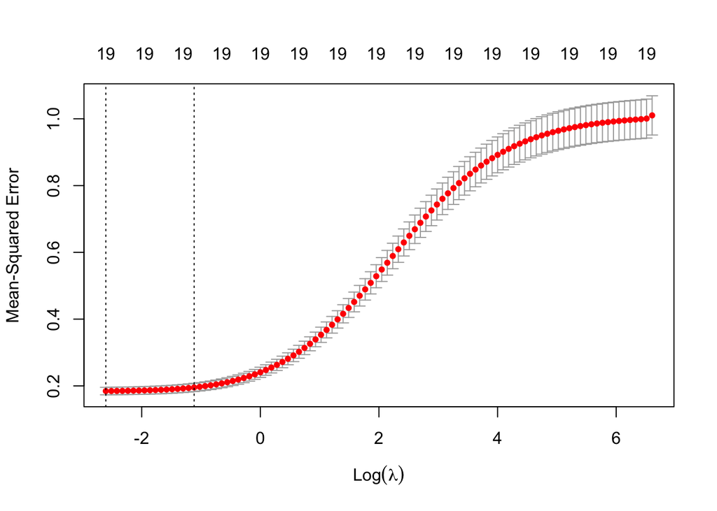

```r
set.seed(1)
cv_out <- cv.glmnet(X[train,], y[train], alpha = 0)
plot(cv_out)
```

```r
cv_out$lambda.min
```

```
## [1] 0.07394278
```

MSE for optimal lambda

```r
pred_ridge_opt <- predict(fit_ridge, s = cv_out$lambda.min, newx = X[test,])
#cv_out$lambda.min, which represents the value of lambda that minimizes the mean cross-validated erro
mean((pred_ridge_opt - y[test])^2)
```

```
## [1] 0.1747112
```

Estimates of the coefficients for the optimal λ

```r
fit_ridge_full <- glmnet(X, y, alpha = 0)
predict(fit_ridge_full, s = cv_out$lambda.min, type = "coefficients")
```

```
## 20 x 1 sparse Matrix of class "dgCMatrix"
##                                            s1
## (Intercept)                     -1.699528e+00
## StatusDeveloping                -1.122420e-01
## Adult.Mortality                 -1.974095e-03
## infant.deaths                    1.828935e-04
## Alcohol                         -1.122711e-02
## percentage.expenditure           2.828359e-05
## Hepatitis.B                     -5.674676e-04
## Measles                          1.445031e-06
## BMI                              4.327120e-03
## under.five.deaths               -4.074445e-04
## Polio                            1.327728e-03
## Total.expenditure                7.424044e-03
## Diphtheria                       2.239917e-03
## HIV.AIDS                        -4.724982e-02
## GDP                              3.277786e-06
## Population                       2.938967e-10
## thinness..1.19.years            -3.850469e-03
## thinness.5.9.years              -2.934580e-03
## Income.composition.of.resources  1.140191e+00
## Schooling                        8.975491e-02
```

The coefficients in the Ridge regression model indicate the strength and direction of the relationships between predictor variables and the response variable. Positive coefficients suggest a positive relationship, negative coefficients suggest a negative relationship, and the magnitude represents the strength of the effect. The coefficient labeled “(Intercept)” represents the baseline value of the response variable.

# Lasso Regularization

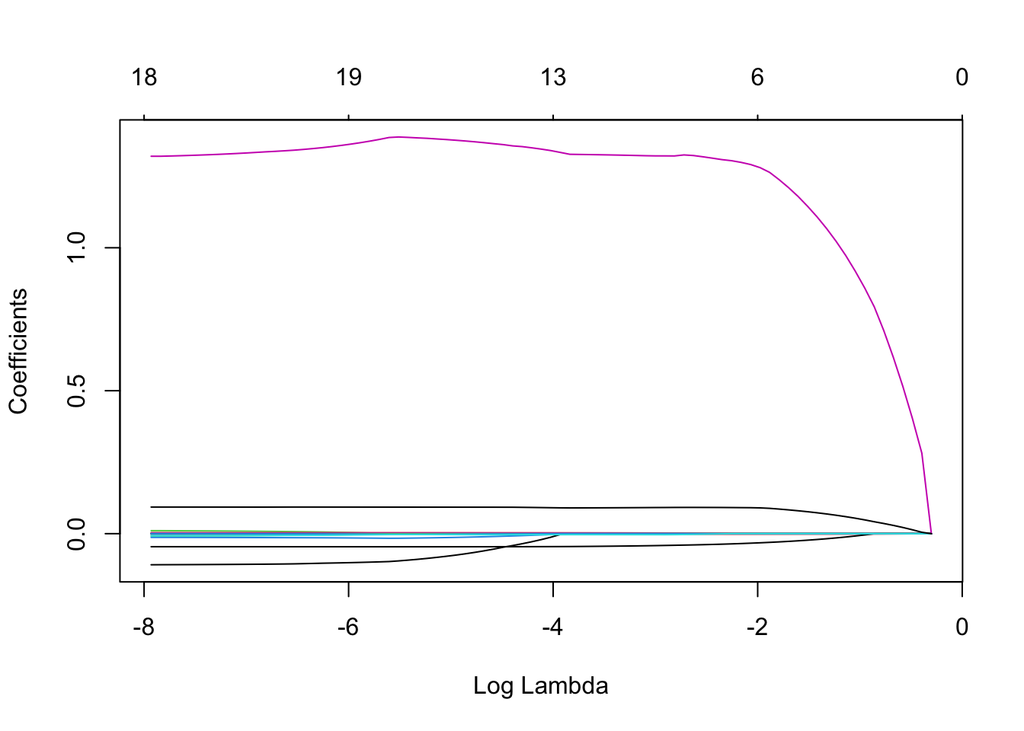

```r
fit_lasso <- glmnet(X[train,], y[train], alpha = 1)
plot(fit_lasso, xvar = "lambda")
```

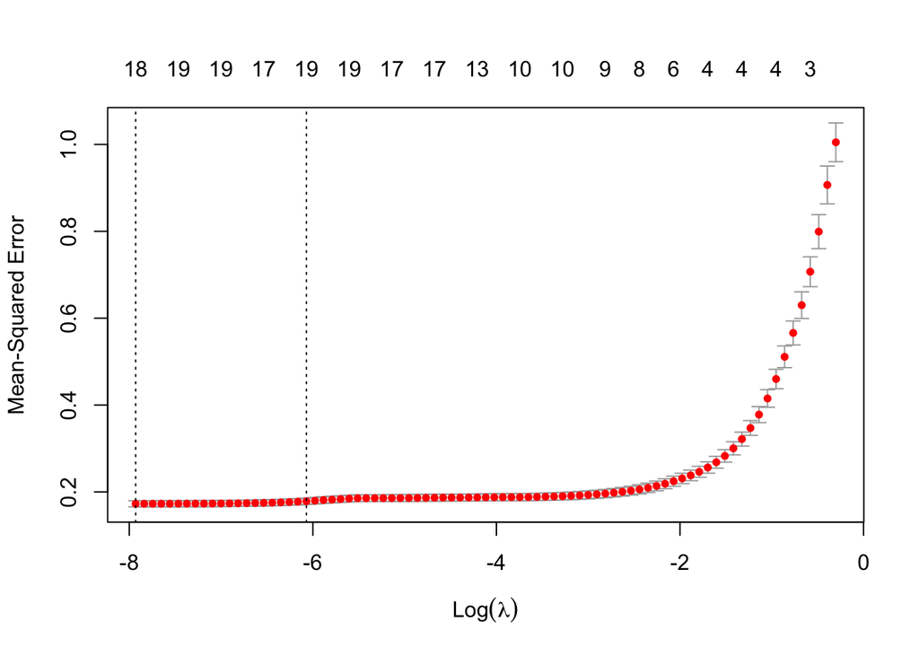

```r
cv_out <- cv.glmnet(X[train,], y[train], alpha = 1)
plot(cv_out)
```

```r
cv_out$lambda.min
```

```
## [1] 0.0003595543
```

```r
pred_lasso <- predict(fit_lasso, s = cv_out$lambda.min, newx = X[test,])
mean((pred_lasso - y[test])^2)
```

```
## [1] 0.1699705
```

```r
fit_lasso_full <- glmnet(X, y, alpha = 1)
predict(fit_lasso_full, s = cv_out$lambda.min, type = "coefficients")
```

```
## 20 x 1 sparse Matrix of class "dgCMatrix"
##                                            s1
## (Intercept)                     -1.715024e+00
## StatusDeveloping                -1.076449e-01
## Adult.Mortality                 -1.918273e-03
## infant.deaths                    8.202924e-03
## Alcohol                         -1.111753e-02
## percentage.expenditure           4.134208e-05
## Hepatitis.B                     -6.966634e-04
## Measles                         -2.091023e-07
## BMI                              3.888713e-03
## under.five.deaths               -6.245131e-03
## Polio                            9.345821e-04
## Total.expenditure                8.241609e-03
## Diphtheria                       1.785464e-03
## HIV.AIDS                        -4.967287e-02
## GDP                              9.989134e-07
## Population                       4.479804e-12
## thinness..1.19.years            -1.429267e-03
## thinness.5.9.years              -4.696173e-03
## Income.composition.of.resources  1.128598e+00
## Schooling                        9.903211e-02
```

# Additive model

```r
gam_model <- gam(Life.expectancy ~ s(Adult.Mortality) + s(infant.deaths) + s(Alcohol) +
                s(percentage.expenditure) + s(Hepatitis.B) + s(Measles) + s(BMI) +
                s(under.five.deaths) + s(Polio) + s(Total.expenditure) + s(Diphtheria) +
                s(HIV.AIDS) + s(GDP) + s(Population) + s(thinness..1.19.years) +
                s(thinness.5.9.years) + s(Income.composition.of.resources) + s(Schooling),
                data = data)

summary(gam_model)
```

```
##
## Family: gaussian
## Link function: identity
##
## Formula:
## Life.expectancy ~ s(Adult.Mortality) + s(infant.deaths) + s(Alcohol) +
##     s(percentage.expenditure) + s(Hepatitis.B) + s(Measles) +
##     s(BMI) + s(under.five.deaths) + s(Polio) + s(Total.expenditure) +
##     s(Diphtheria) + s(HIV.AIDS) + s(GDP) + s(Population) + s(thinness..1.19.years) +
##     s(thinness.5.9.years) + s(Income.composition.of.resources) +
##     s(Schooling)
##
## Parametric coefficients:
##               Estimate Std. Error t value Pr(>|t|)
## (Intercept) -3.976e-13  6.671e-03       0        1
##
## Approximate significance of smooth terms:
##                                      edf Ref.df      F  p-value
## s(Adult.Mortality)                 7.665  8.515 47.523  < 2e-16 ***
## s(infant.deaths)                   5.064  5.917  5.307 3.19e-05 ***
## s(Alcohol)                         5.184  6.307  7.450  < 2e-16 ***
## s(percentage.expenditure)          3.289  4.256  4.606 0.000868 ***
## s(Hepatitis.B)                     1.000  1.000  0.014 0.905119
## s(Measles)                         1.000  1.000  0.253 0.615091
## s(BMI)                             8.176  8.802  7.363  < 2e-16 ***
## s(under.five.deaths)               4.973  5.788  6.155 5.46e-06 ***
## s(Polio)                           6.589  7.565  2.282 0.022328 *
## s(Total.expenditure)               5.912  7.103  9.838  < 2e-16 ***
## s(Diphtheria)                      2.358  2.922  2.174 0.089632 .
## s(HIV.AIDS)                        8.749  8.976 60.681  < 2e-16 ***
## s(GDP)                             8.501  8.894  3.947 4.00e-05 ***
## s(Population)                      3.671  4.415  3.387 0.014020 *
## s(thinness..1.19.years)            7.486  8.103  9.792  < 2e-16 ***
## s(thinness.5.9.years)              2.053  2.358  4.338 0.005743 **
## s(Income.composition.of.resources) 7.617  8.502 48.032  < 2e-16 ***
## s(Schooling)                       8.750  8.975  6.555  < 2e-16 ***
## ---
## Signif. codes:  0 '***' 0.001 '**' 0.01 '*' 0.05 '.' 0.1 ' ' 1
##
## R-sq.(adj) =  0.927   Deviance explained = 93.1%
## GCV = 0.078062  Scale est. = 0.073373  n = 1649
```

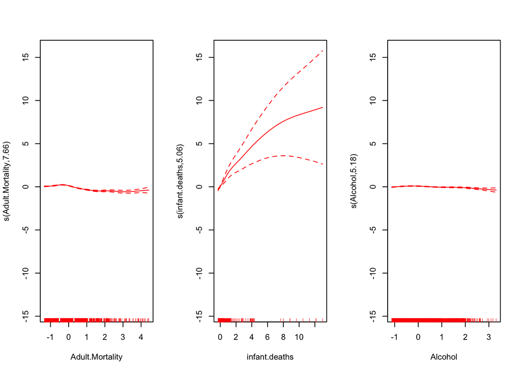

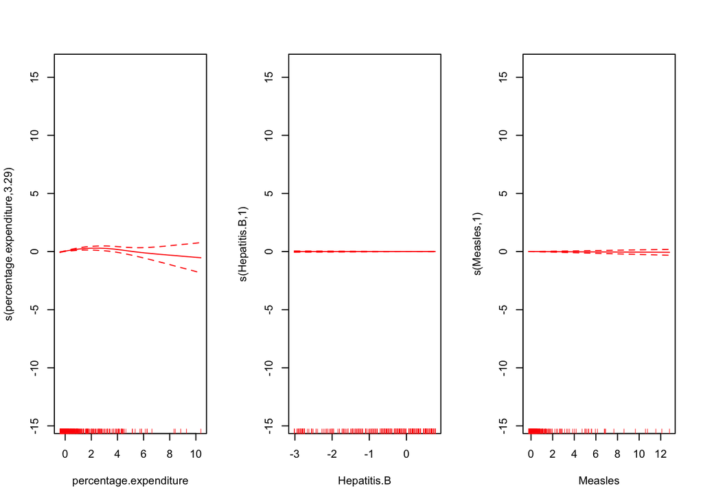

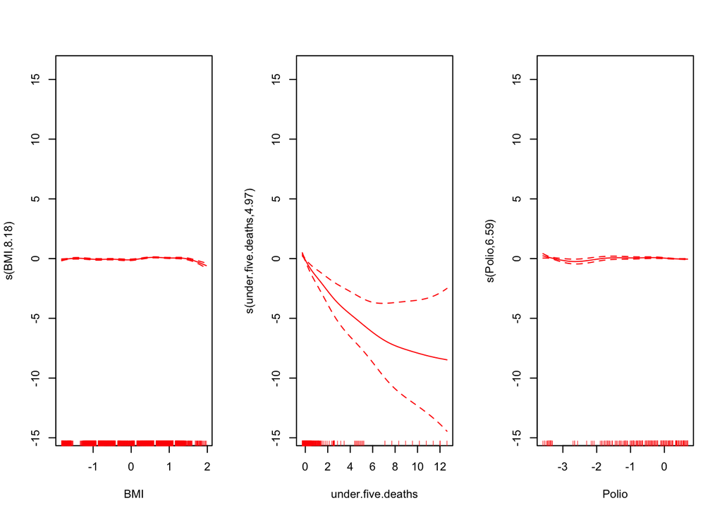

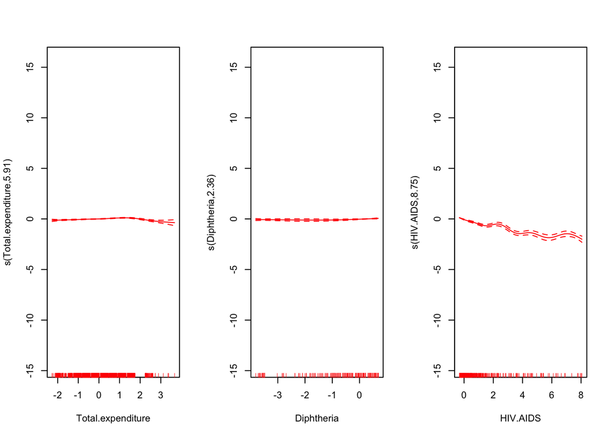

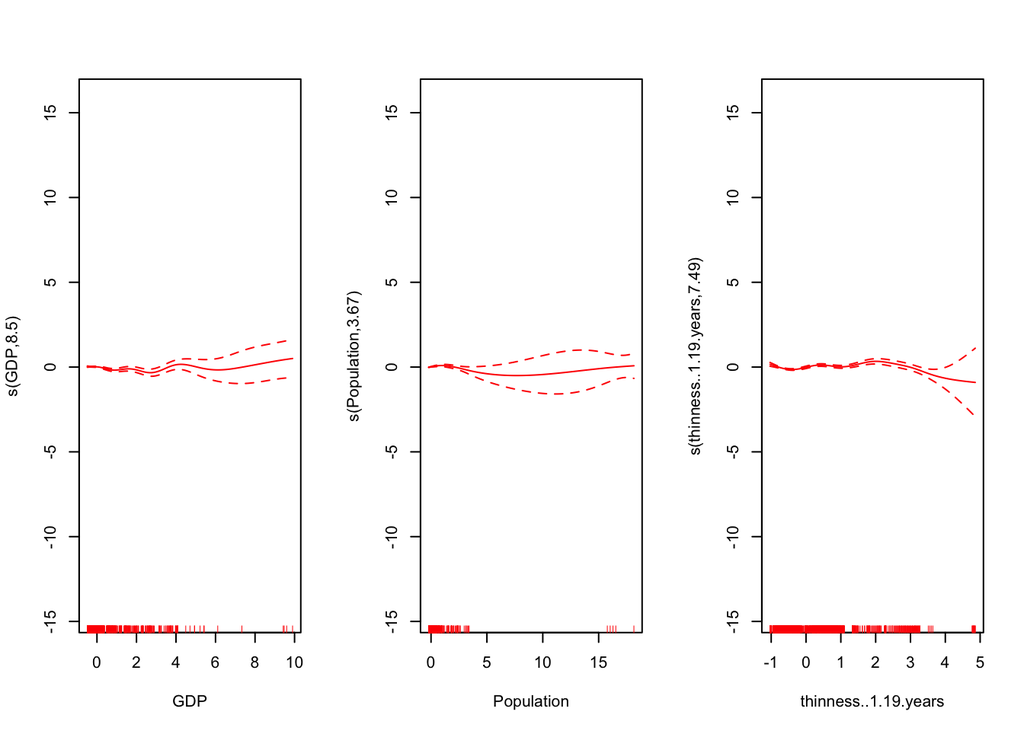

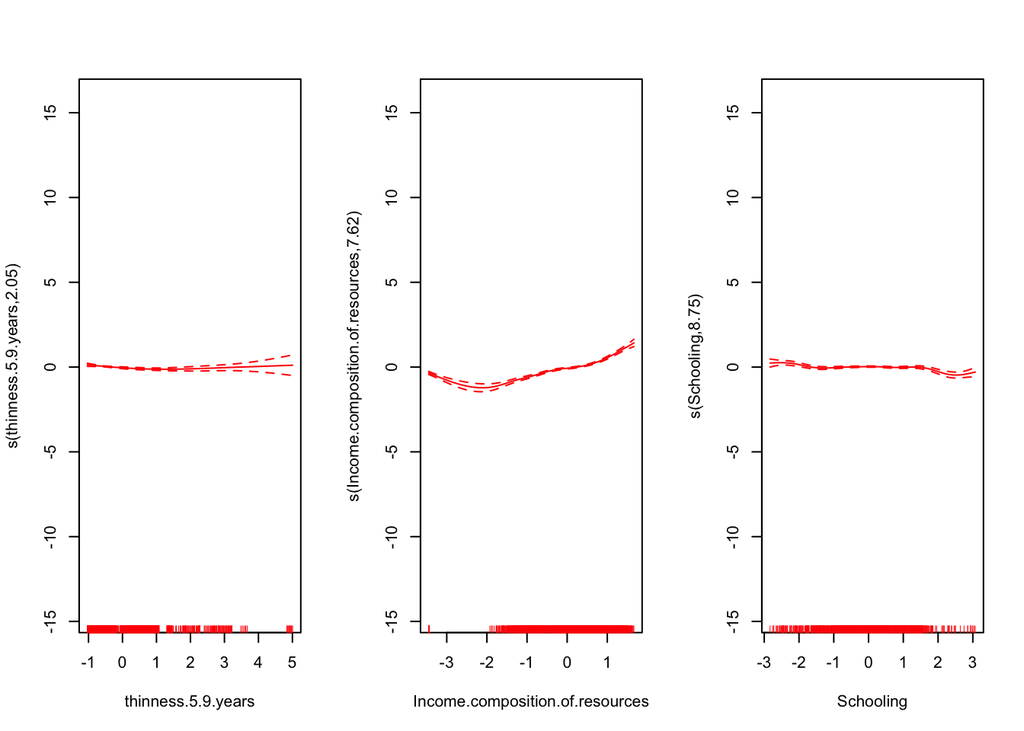

```r
par(mfrow = c(1, 3))
plot(gam_model, col = "red", se = TRUE)
```

From the plots above we can see that the most sloping curves are for variables: infant deaths, under.five.deaths, HIV.AIDS, Income.composition.of.recources

# Decision trees

```r
regression_tree <- tree(Life.expectancy ~ ., data= data_not_scaled)
summary(regression_tree)
```

```
##
## Regression tree:
## tree(formula = Life.expectancy ~ ., data = data_not_scaled)
## Variables actually used in tree construction:
## [1] "Income.composition.of.resources" "HIV.AIDS"
## [3] "Adult.Mortality"                 "thinness..1.19.years"
## Number of terminal nodes:  10
## Residual mean deviance:  9.704 = 15900 / 1639
## Distribution of residuals:
##      Min.   1st Qu.    Median      Mean   3rd Qu.      Max.
## -13.61000  -1.87200   0.08767   0.00000   1.72100  14.97000
```

The most significant predictors that were used in creating the decision tree:

- Income.composition.of.resources
- HIV.AIDS
- Adult.Mortality
- thinness..1.19.years

Plotting the tree

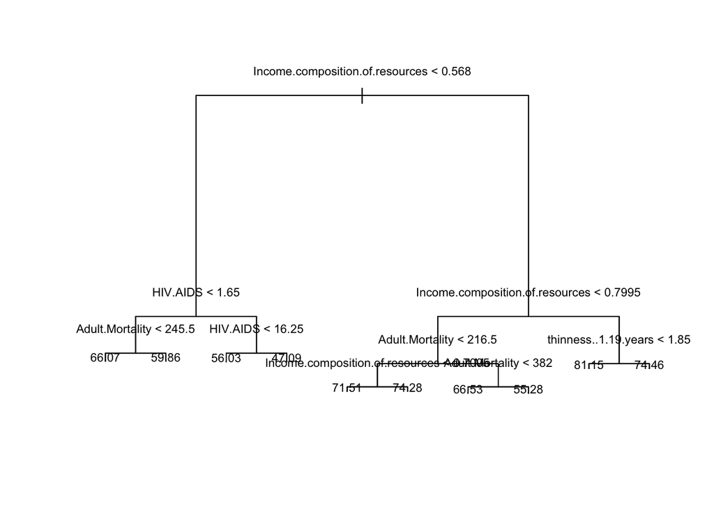

```r
plot(regression_tree)
text(regression_tree, cex = 0.7, adj = c(0, 0.5), pos = 3)
```

Calculating the test error

```r
set.seed(1)
n <- nrow(data_not_scaled)
train <- sample(n, n / 2)
test <- -train
regression_tree <- tree(Life.expectancy ~ ., data = data_not_scaled, subset = train)
life_expectancy_pred <- predict(regression_tree, newdata = data_not_scaled[test,])
```

```r
mean((life_expectancy_pred - data_not_scaled$Life.expectancy[test])^2)
```

```
## [1] 11.30585
```

Choosing optimal subtree

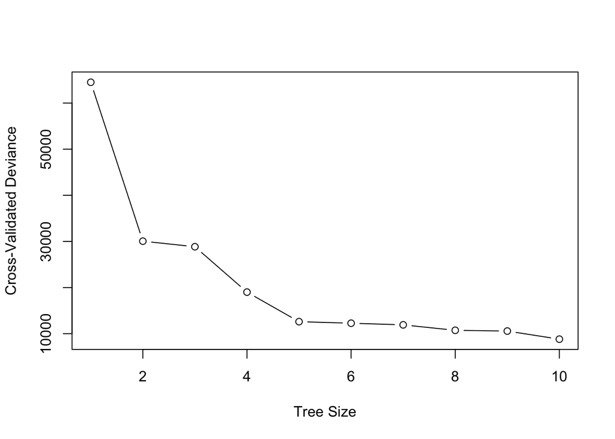

```r
life_expectancy_cv <- cv.tree(regression_tree)
plot(life_expectancy_cv$size, life_expectancy_cv$dev, type = "b",
     xlab = "Tree Size", ylab = "Cross-Validated Deviance")
```

We can see that for tree size bigger than 5, the cross-validated deviance does not drops significantly

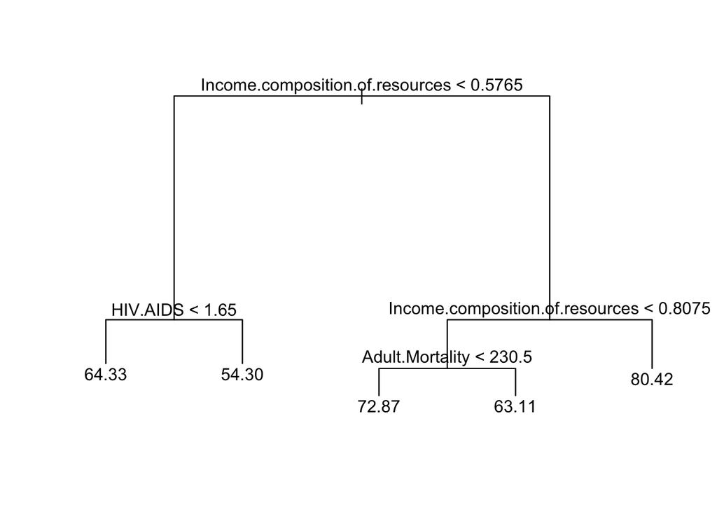

```r
tree_pruned <- prune.tree(regression_tree, best = 5)
plot(tree_pruned)
text(tree_pruned)
```

```r
life_expectancy_pred_pruned <- predict(tree_pruned, newdata = data_not_scaled[test,])
mean((life_expectancy_pred_pruned - data_not_scaled$Life.expectancy[test])^2)
```

```
## [1] 17.77761
```

Creating more complicated tree.

```r
regression_tree_deeper <- tree(Life.expectancy ~ ., data = data_not_scaled, subset = train, mindev = 0.0001)
life_expectancy_pred_deeper <- predict(regression_tree_deeper, newdata = data_not_scaled[test,])
mean((life_expectancy_pred_deeper - data_not_scaled$Life.expectancy[test])^2)
```

```
## [1] 6.814987
```

By reducing the mindev value, we allow the tree to become more complex. As shown abpw, this leads to a significant decrease in the mean squared error (MSE) compared to the two earlier trees.

# Random Forest

Building the model:

```r
set.seed(213)
train_indices <- sample(nrow(data_not_scaled), nrow(data_not_scaled) * 0.8)
train_data_not_scaled <- data_not_scaled[train_indices, ]
test_data_not_scaled <- data_not_scaled[-train_indices, ]
```

```r
set.seed(2)
model_rf <- randomForest(Life.expectancy ~., data = train_data_not_scaled, importance = TRUE)
```

```r
model_rf
```

```
##
## Call:
##  randomForest(formula = Life.expectancy ~ ., data = train_data_not_scaled,      importance = TRUE)
##                Type of random forest: regression
##                      Number of trees: 500
## No. of variables tried at each split: 6
##
##           Mean of squared residuals: 3.358505
##                     % Var explained: 95.61
```

Default model has 500 trees and takes 6 random variables while splitting every tree. MSE on training data is 3.35 which is satisfying result. Model explains 96% of variance.

```r
predict_rf <- predict(model_rf, newdata = test_data_not_scaled)
mean((predict_rf - test_data_not_scaled$Life.expectancy)^2)
```

```
## [1] 3.630535
```

MSE on testing data is very similar to MSE on training data - 3.6.

```r
model_rf$importance
```

```
##                                    %IncMSE IncNodePurity
## Status                           0.2016776      173.1803
## Adult.Mortality                 19.3004288    16868.4517
## infant.deaths                    1.9876668     1176.4601
## Alcohol                          2.9947704     1757.0468
## percentage.expenditure           1.4183325     1866.4168
## Hepatitis.B                      0.3432123      367.9745
## Measles                          0.4702402      430.0259
## BMI                              4.3121808     5039.5424
## under.five.deaths                2.8632368     2296.2877
## Polio                            0.6269317      581.4637
## Total.expenditure                1.2268348     1016.3547
## Diphtheria                       0.6438194      584.4866
## HIV.AIDS                        19.8041788    22691.9162
## GDP                              1.4255020     1147.4558
## Population                       0.2855405      420.8644
## thinness..1.19.years             4.1258047     3217.5730
## thinness.5.9.years               5.1197969     4144.7635
## Income.composition.of.resources 25.8158093    27691.4214
## Schooling                        6.2630166     8862.6530
```

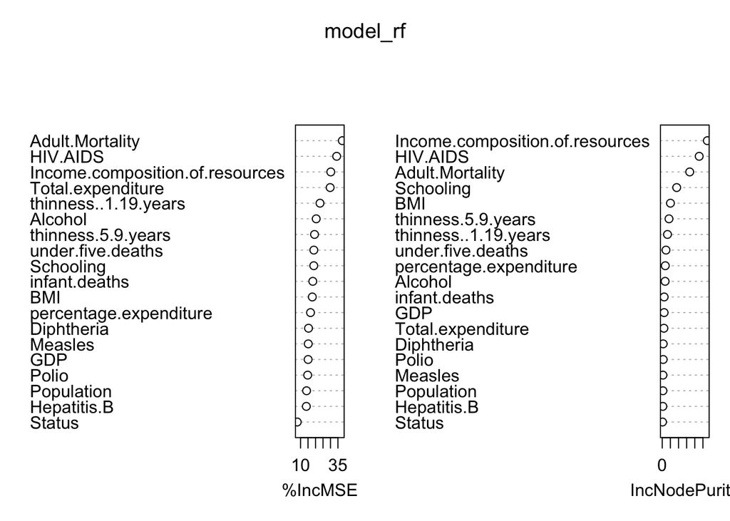

```r
varImpPlot(model_rf)
```

From the list and plots above we see that:

```r
#The value of %IncMSE for a given predictor represents the percentage increase in mean squared error when that predictor is randomly rearranged in the training data and re-prediction is performed. Higher values of %IncMSE for a predictor indicate that this predictor is more important for model prediction. #The IncNodePurity value for a given predictor measures the increment of node purity when the tree is partitioned according to that predictor.
```